[figure not shown]

IDI-24

Steering Switch

INSTRUMENTATION/DRIVER INFO

11.Steering Switch

A: REMOVAL

CAUTION:

Before handling the airbag module, refer to “CAUTION” of “General Description” in “AIRBAG SYS-

TEM”. <Ref. to AB-9, CAUTION, General Description.>

1) Set the tire to the straight-ahead position.

2) Disconnect the ground cable from battery and wait for at least 60 seconds before starting work. <Ref. to

NT-5, BATTERY, NOTE, Note.>

NOTE:

For models other than STI model, disconnect the ground terminal from battery sensor.

3) Remove the driver’s airbag module. <Ref. to AB-33, REMOVAL, Driver’s Airbag Module.>

4) Remove the steering wheel. <Ref. to PS-16, REMOVAL, Steering Wheel.>

5) Remove the MID switch. <Ref. to PS-17, DISASSEMBLY, Steering Wheel.>

B: INSTALLATION

CAUTION:

• Before handling the airbag module, refer to “CAUTION” of “General Description” in “AIRBAG SYS-

TEM”. <Ref. to AB-9, CAUTION, General Description.>

• Do not allow harness and connectors to interfere or get tangled up with other parts.

• Make sure that the steering roll connector is not turned from the original position.

• If the steering wheel and steering angle sensor (steering roll connector) are removed, perform

“VDC sensor midpoint setting mode” of the VDC. <Ref. to VDC-16, VDC SENSOR MIDPOINT SETTING

MODE, ADJUSTMENT, VDC Control Module and Hydraulic Control Unit (VDCCM&H/U).>

• Securely install the switch. Improper insertion of the pin or claw of the switch may cause improper

installation.

1) Install the MID switch. <Ref. to PS-19, ASSEMBLY, Steering Wheel.>

2) Align the center position of the steering roll connector. <Ref. to AB-64, ADJUSTMENT, Roll Connector.>

3) Install the steering wheel.

Tightening torque:

39 N·m (4.0 kgf-m, 28.8 ft-lb)

Clearance:

Between cover assembly - column and steering wheel: 4 — 6 mm (0.16 — 0.24 in)

4) Install the driver’s airbag module. <Ref. to AB-34, INSTALLATION, Driver’s Airbag Module.>

5) Connect the battery ground terminal. <Ref. to NT-5, BATTERY, NOTE, Note.>

NOTE:

For models other than STI model, connect the ground terminal to battery sensor.

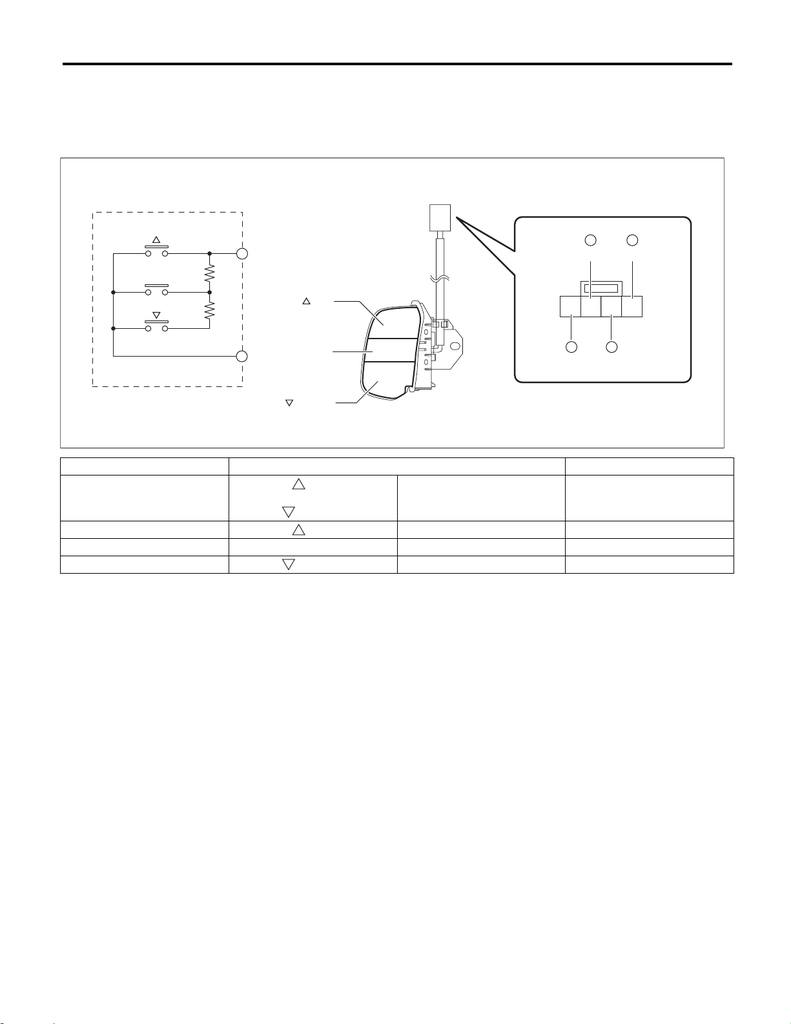

IDI-25

Steering Switch

INSTRUMENTATION/DRIVER INFO

C: INSPECTION

1) Measure the resistance between connector terminals.

Preparation tool:

Circuit tester

2) Replace the MID switch if the inspection result is not within the standard value.

Terminal No. Inspection conditions Standard

All OFF Approx. 1 MΩ or more

3 — 2 (UP) ON Less than 1 Ω

3 — 2 i/SET ON Approx. 1000 Ω

3 — 2 (DOWN) ON Approx. 3670 Ω

[figure not shown]

IDI-26

Steering Switch

INSTRUMENTATION/DRIVER INFO

[figure not shown]

INSTRUMENTATION/DRIVER INFO (DIAG-

NOSTICS)

IDI(diag)

Page

1. Basic Diagnostic Procedure .......................................................................2

2. Check List for Interview ..............................................................................4

3. General Description ...................................................................................5

4. Electrical Component Location ..................................................................6

5. Control Module I/O Signal ..........................................................................7

6. Subaru Select Monitor ..............................................................................10

7. Read Diagnostic Trouble Code (DTC) .....................................................14

8. Clear Memory Mode .................................................................................15

9. Inspection Mode .......................................................................................16

10. Read Current Data ...................................................................................17

11. System Operation Check Mode ...............................................................20

12. User Customizing .....................................................................................22

13. List of Diagnostic Trouble Code (DTC) ....................................................23

14. Diagnostic Procedure with Diagnostic Trouble Code (DTC) ....................25

15. Diagnostics with Phenomenon .................................................................35